# Modeling UK quarterly Income

Andrea Schioppa

## Synopsis

We use the data set income.dta available from [Verbeek’s data sets](http://bcs.wiley.com/he-bcs/Books?action=resource&bcsId=7080&itemId=1119951674&resourceId=27088) (Chapter 8), which contains UK quarterly income (in millions of pounds and current prices) for the terms 1971:I to 1985:II ($T = 58$), to illustrate the choice of an ARIMA model.

## Loading the data and creating a plot

We load the data and plot the income after transforming it by $\log$.

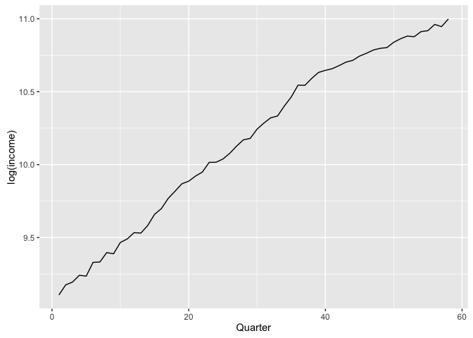

```r
library(foreign)
library(ggplot2)
library(scales)
library(zoo)
library(forecast)
income <- read.dta('../income.dta')
# plot
p <- ggplot(income, aes(x=time, y=log(income))) + geom_line()
p <- p + labs(x = 'Quarter', y ='log(income)')
p
```

The graph suggests either a trend or a unit root. We run an AR(1) Dickey-Fuller test: the null hypothesis is the presence of a unit root, the statistic is computed like a $t$-statistic, but the distribution is special; at the same significance level for a $z$-test, the values for rejection are more extreme. We test both with and without a time trend.

```r
# Fit an AR(1) to run the Dickey-Fuller test
ts <- with(income, zoo(log(income), time))
ar_df <- arima(ts, order = c(1,0,0))

ar_df
```

```
##
## Call:
## arima(x = ts, order = c(1, 0, 0))
##
## Coefficients:
##          ar1  intercept
##       0.9990    10.0597
## s.e.  0.0014     0.9185
##
## sigma^2 estimated as 0.001756:  log likelihood = 98.6,  aic = -191.2
```

```r
# Dickey-Fuller, needs a special table
# on 58 observations we fail to reject the unit root
DFstat <- (ar_df$coef[1]-1)/sqrt(ar_df$var.coef[1,1]) # -0.7080838

DFstat
```

```
##        ar1
## -0.7080838
```

```r
# Redo with a time trend : again fail to reject the unit root
ar_dfTrend <- arima(ts, order = c(1, 0, 0), xreg = income$time)
DFstatTrend <- (ar_dfTrend$coef[1]-1)/sqrt(ar_dfTrend$var.coef[1,1]) # -1.2706

DFstatTrend
```

```
##       ar1
## -1.270555
```

Both with an without a time trend we fail to reject the presence of a unit root.

## Augmented Dickey-Fuller

The test might be incorrect because we fail to specify the autoregression correctly. We thus run Augmented Dickey-Fuller tests up to order AR(6). We have implemented both the version with the time trend and without.

```r
#################################################
# b : Augmented Dickey-Fuller tests up to AR(6) #
#################################################

# lags a vector; helper to lagged_Matrix;
# R standard lag gave some issues
lagged_vector <- function(x, lag = 1) {
    N = length(x)
    return(c(rep(0, lag), x[-c((N-lag+1):N)]))
}


# construct a matrix with lags
lagged_Matrix <- function(x, lags) {
    out <- matrix(0, nrow = length(x), ncol = lags+1)
    colnames(out) <- paste('lag', 0:lags, sep = '')

    out[,'lag0'] <- x

    j = 1
    while(j <= lags) {
        out[, paste('lag', j, sep = '')] <- lagged_vector(x, j)
        j <- j + 1
    }

    out
}

# performs multiple Augmented DF tests
augmentedDF <- function(tser, lags, trend = FALSE) {

    # convert tser to numeric
    tsnum <- as.numeric(tser)
    diffts <- tsnum[-1] - tsnum[-length(tsnum)]

    # construct dimensions
    lagmat.dim <- ifelse(trend, lags + 3, lags + 2)
    T <- length(diffts)

    # construct lagmat = matrix with lags for fitting
    lagmat <- matrix(0, nrow = T, ncol = lagmat.dim)
    lagged <- lagged_Matrix(diffts, lags = lags)

    if(trend) { # 'extvar' is the variable we're interested in
        # 'trend' is the time trend
        lagmat[,-c((lagmat.dim-1):lagmat.dim)] <- lagged
        colnames(lagmat) <- c('DepVar', colnames(lagged)[-1],'extvar', 'trend')
    } else {
        lagmat[,-c(lagmat.dim)] <- lagged
        colnames(lagmat) <- c('DepVar', colnames(lagged)[-1], 'extvar')
    }

    lagmat[, 'extvar'] <- tsnum[-T]
    if(trend) lagmat[, 'trend'] <- index(tser)[-1]

    lagmat <- as.data.frame(lagmat)

    # output vector
    out <- rep(0, lags+1)
    names(out) <- paste('AugDF(', c(0:lags), ')', sep = '')
    if(trend) trendout <- out
    # output matrix
    for(j in c(0:lags)) {
        # construct model formula
        strmod <-'DepVar ~ '
        start.row <- 1 # row where to start the fitting

        if(j >= 1) {
            start.row <- start.row + j
            strmod <- paste(strmod, paste(colnames(lagmat)[2:(j+1)], collapse = ' + '))
        }

        strmod <- paste(strmod, 'extvar', sep = ' + ')
        if(trend) strmod <- paste(strmod, 'trend', sep = ' + ')

        # fit and extract statistic; DF is computed like a t-stat, but
        # has a special distribution
        model <- lm(as.formula(strmod), data = lagmat[c(start.row:T),])
        DFstat <- coef(model)['extvar']/sqrt(vcov(model)['extvar', 'extvar'])

        # assign
        out[j+1] <- DFstat

        if(trend) {
            TrendStat <- coef(model)['trend']/sqrt(vcov(model)['trend', 'trend'])
            trendout[j] <- TrendStat
        }
    }

    if(trend) {
        return(list(DF = out, Trend = trendout))
    } else {
        return(out)
    }
}

ADFstats <- augmentedDF(ts, lags = 6) # fail to reject unit root
ADFstats
```

```
##  AugDF(0)  AugDF(1)  AugDF(2)  AugDF(3)  AugDF(4)  AugDF(5)  AugDF(6)
## -2.300915 -2.942889 -2.245276 -2.712517 -2.350789 -1.672587 -2.228759
```

```r
ADFstatsTrend <- augmentedDF(ts, lags = 6, trend = TRUE)[[1]] # fail to reject unit root
ADFstatsTrend
```

```
##    AugDF(0)    AugDF(1)    AugDF(2)    AugDF(3)    AugDF(4)    AugDF(5)
## -0.44230176  0.72763466  0.12322149  0.72759020 -0.50299971 -0.72335325
##    AugDF(6)
##  0.08210504
```

We fail to reject the unit root.

## First differences

We explore if taking first differences removes the unit root. We first create a plot.

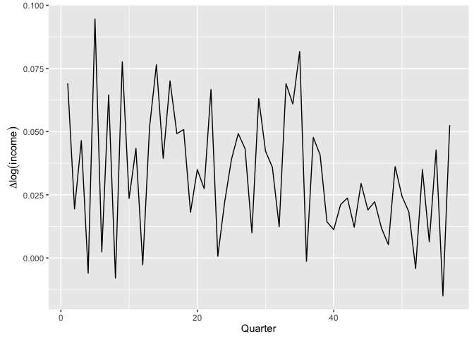

```r
income$diff <- with(income, c(diff(log(income)), 0))
# plot
pdiff <- ggplot(income[-dim(income)[1],], aes(x=time, y=diff)) + geom_line()
pdiff <- pdiff + xlab('Quarter') + ylab(expression(Delta * log(income)))
pdiff
```

We now use the Augmented Dickey-Fuller test. This time we can reject the unit root on the differenced process. Note that the time trend does not result statistically significant.

```r
IADFstats <- augmentedDF(diff(ts), lags = 6) # In ADF of orders 0 and 1 reject unit root
IADFstats
```

```
##   AugDF(0)   AugDF(1)   AugDF(2)   AugDF(3)   AugDF(4)   AugDF(5)
## -8.2491419 -3.0241087 -2.8085025 -1.0230944 -0.5576053 -1.0033825
##   AugDF(6)
## -0.7087261
```

```r
IADFstatsTrend <- augmentedDF(diff(ts), lags = 6, trend = TRUE) # time trend not significant
IADFstatsTrend
```

```
## $DF
##   AugDF(0)   AugDF(1)   AugDF(2)   AugDF(3)   AugDF(4)   AugDF(5)
## -8.5432052 -3.2015044 -3.0552546 -1.3253883 -0.6754907 -1.1832414
##   AugDF(6)
## -0.8550203
##
## $Trend
##   AugDF(0)   AugDF(1)   AugDF(2)   AugDF(3)   AugDF(4)   AugDF(5)
## -1.0436070 -1.1831805 -0.9974237 -0.4203475 -0.6781532 -0.5255157
##   AugDF(6)
##  0.0000000
```

## Exploratory Analysis on Integrated Differences

We first plot the autocorrelation and partial autocorrelation functions of the first-order differences.

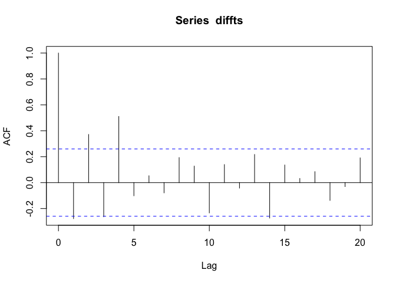

```r
diffts <- diff(ts)
acf_diffts <- acf(diffts, lag.max = 20) # exclude autocorrelation
```

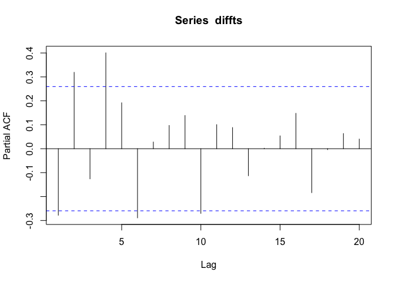

```r
pacf_diffts <- pacf(diffts, lag.max = 20)
```

The pictures suggest trying an ARMA of order(s) $\le 4$. We first try AR(4) and MA(4).

```r
armaModels <- list()
armaModels[['AR(4)']] <- arima(ts, order = c(4, 1, 0))
armaModels[['MA(4)']] <- arima(ts, order = c(0, 1, 4))
armaModels
```

```
## $`AR(4)`
##
## Call:
## arima(x = ts, order = c(4, 1, 0))
##
## Coefficients:
##          ar1     ar2     ar3     ar4
##       0.0231  0.3055  0.0288  0.5764
## s.e.  0.1076  0.1051  0.1097  0.1077
##
## sigma^2 estimated as 0.0004404:  log likelihood = 137.72,  aic = -265.43
##
## $`MA(4)`
##
## Call:
## arima(x = ts, order = c(0, 1, 4))
##
## Coefficients:
##          ma1     ma2     ma3     ma4
##       0.1755  0.5850  0.1347  0.5577
## s.e.  0.1217  0.1366  0.1396  0.0979
##
## sigma^2 estimated as 0.0007125:  log likelihood = 124.75,  aic = -239.5
```

```r
# Info Matrix
arma_infcr <- matrix(0, nrow = length(armaModels), ncol = 2)
rownames(arma_infcr) <- names(armaModels)
colnames(arma_infcr) <- c('AIC', 'BIC')
arma_infcr[, 1] <- unlist(sapply(armaModels, `[`, 'aic'))
arma_infcr[, 2] <- sapply(armaModels, BIC)
arma_infcr
```

```
##             AIC       BIC
## AR(4) -265.4331 -255.2178
## MA(4) -239.5014 -229.2861
```

```r
Ljung_Box_Test <- function(x, K) {
    T <- x$nobs
    ndf <- K - (length(x$coef) - 1)
    if(ndf <= 0 || T <= K) return(NA) # can't apply the statistics

    # autocorrelations
    rk <- acf(x$residuals, lag.max = K, plot = FALSE)
    rk <- as.numeric(rk$acf)[-1] # first is lag = 0


    # weights
    wk <- 1/(T-c(1:K))

    # Q-statistic
    Q <- T * (T+2) * sum(wk * rk^2)

    return(pchisq(Q, df = ndf, lower.tail = FALSE))
}

Kvec <- c(6, 12, 18)
arlj_pvals <- matrix(0, nrow = length(armaModels), ncol = length(Kvec))
rownames(arlj_pvals) <- names(armaModels)
colnames(arlj_pvals) <- paste('K =', Kvec)

for(i in 1:length(Kvec)) {
    arlj_pvals[,i] <- sapply(armaModels, Ljung_Box_Test, K = Kvec[i])
}

arlj_pvals
```

```
##            K = 6      K = 12     K = 18
## AR(4) 0.24787084 0.128945277 0.06000249
## MA(4) 0.04772276 0.007368665 0.01081223
```

## Choice of a model

We construct a grid of models to choose one.

```r
# fit  models up to ARIMA(5,1,5)
armaModels <- list()
# some models will not converge
errorList <- list()
warningList <- list()
for(ari in 0:5) {
    for(mi in 0:5) {
        str.name <- paste('ARIMA(', ari, ',1,', mi, ')', sep = '')
        tryCatch({
            # when I \ne 0 intercept is not included;
            # I did not assume a time trend so I will exclude
            # if you want to include add , xreg = rep(1,length(ts)
            armaModels[[str.name]] <- arima(ts, order = c(ari,1,mi))
        }, warning = function(war) {
            a <- get('warningList', envir = globalenv())
            a[[str.name]] <- war$message
            assign('warningList', a, envir = globalenv())#[[str.name]] <- err$message


        }, error = function(err) {
            # need to copy from the Global Environment
            a <- get('errorList', envir = globalenv())
            a[[str.name]] <- err$message
            assign('errorList', a, envir = globalenv()) # need to go in the globalenv
        })
    }
}

# Failed only ARIMA(4,1,3)
errorList
```

```
## $`ARIMA(4,1,3)`
## [1] "non-stationary AR part from CSS"
```

```r
armaPvals <- lapply(armaModels, function(x) {
    if(length(x$coef) == 0) return(NA) # handles the empty model ARIMA(0,1,0)

    out <- data.frame(z = x$coef/sqrt(diag(x$var.coef)), row.names = names(x$coef))
    # note: we compute asymmetric ones, with just one tail
    out$pval = pnorm(abs(out$z), lower.tail=F)

    out
})
armaPvals
```

```
## $`ARIMA(0,1,0)`
## [1] NA
##
## $`ARIMA(0,1,1)`
##            z        pval
## ma1 2.741667 0.003056415
##
## $`ARIMA(0,1,2)`
##            z         pval
## ma1 7.736346 5.115719e-15
## ma2 5.450352 2.513516e-08
##
## $`ARIMA(0,1,3)`
##              z         pval
## ma1  4.4157297 5.033490e-06
## ma2  4.5198950 3.093515e-06
## ma3 -0.8569156 1.957458e-01
##
## $`ARIMA(0,1,4)`
##             z         pval
## ma1 1.4414365 7.473071e-02
## ma2 4.2834990 9.198845e-06
## ma3 0.9654629 1.671565e-01
## ma4 5.6962610 6.123169e-09
##
## $`ARIMA(0,1,5)`
##            z         pval
## ma1 1.700752 4.449482e-02
## ma2 4.330825 7.427587e-06
## ma3 1.268400 1.023275e-01
## ma4 4.966139 3.414956e-07
## ma5 1.257728 1.042450e-01
##
## $`ARIMA(1,1,0)`
##           z         pval
## ar1 4.51609 3.149597e-06
##
## $`ARIMA(1,1,1)`
##             z         pval
## ar1 252.76603 0.000000e+00
```

[output cut: 222 more lines]

```
## ma3  1.5562062 5.982953e-02
## ma4 -0.8769749 1.902501e-01
##
## $`ARIMA(5,1,5)`
##              z          pval
## ar1 -26.707782 1.911268e-157
## ar2  -1.813138  3.490526e-02
## ar3   0.994435  1.600056e-01
## ar4  30.311951 3.988541e-202
## ar5  43.615401  0.000000e+00
## ma1   7.515037  2.844741e-14
## ma2   2.625039  4.331952e-03
## ma3   1.071715  1.419241e-01
## ma4  -2.264675  1.176632e-02
## ma5  -5.342641  4.580094e-08
```

```r
# Information Criteria
arma_infcr <- matrix(0, nrow = length(armaModels), ncol = 2)
rownames(arma_infcr) <- names(armaModels)
colnames(arma_infcr) <- c('AIC', 'BIC')
arma_infcr[, 1] <- unlist(sapply(armaModels, `[`, 'aic'))
arma_infcr[, 2] <- sapply(armaModels, BIC)
arma_infcr
```

```
##                    AIC       BIC
## ARIMA(0,1,0) -197.8778 -195.8347
## ARIMA(0,1,1) -202.7158 -198.6297
## ARIMA(0,1,2) -226.5925 -220.4633
## ARIMA(0,1,3) -225.2936 -217.1214
## ARIMA(0,1,4) -239.5014 -229.2861
## ARIMA(0,1,5) -239.3781 -227.1198
## ARIMA(1,1,0) -213.0459 -208.9598
## ARIMA(1,1,1) -246.6309 -240.5017
## ARIMA(1,1,2) -225.5898 -217.4176
## ARIMA(1,1,3) -251.8751 -241.6599
## ARIMA(1,1,4) -254.7082 -242.4499
## ARIMA(1,1,5) -260.4652 -246.1639
## ARIMA(2,1,0) -247.2839 -241.1548
## ARIMA(2,1,1) -255.7328 -247.5606
## ARIMA(2,1,2) -259.7144 -249.4991
## ARIMA(2,1,3) -258.3077 -246.0494
## ARIMA(2,1,4) -260.8182 -246.5168
## ARIMA(2,1,5) -260.6218 -244.2774
## ARIMA(3,1,0) -245.7280 -237.5558
## ARIMA(3,1,1) -244.1215 -233.9063
## ARIMA(3,1,2) -257.8376 -245.5793
## ARIMA(3,1,3) -267.1860 -252.8846
## ARIMA(3,1,4) -262.3933 -246.0489
## ARIMA(3,1,5) -265.5364 -247.1489
## ARIMA(4,1,0) -265.4331 -255.2178
## ARIMA(4,1,1) -264.7949 -252.5366
## ARIMA(4,1,2) -273.7878 -259.4864
## ARIMA(4,1,4) -273.6526 -255.2652
## ARIMA(4,1,5) -273.1861 -252.7556
## ARIMA(5,1,0) -265.7096 -253.4513
## ARIMA(5,1,1) -267.7321 -253.4307
## ARIMA(5,1,2) -272.9799 -256.6354
## ARIMA(5,1,3) -271.0682 -252.6808
## ARIMA(5,1,4) -269.8328 -249.4023
## ARIMA(5,1,5) -279.4581 -256.9845
```

AIC chooses ARIMA(5,1,5), BIC ARIMA(4,1,2). AIC is generally less conservative; we now test for the presence of common roots. In case of common roots one can choose a more parsimonious model.

```r
coef1 <- armaModels$`ARIMA(4,1,2)`$coef
coef2 <- armaModels$`ARIMA(5,1,5)`$coef

# test for common roots
arcoef1 <- polyroot(c(1, -coef1[1:4]))
arcoef1
```

```
## [1]  0.005303+1.00132i -1.111549-0.00000i  0.005303-1.00132i
## [4]  1.044051+0.00000i
```

```r
macoef1 <- polyroot(c(1, coef1[5:6]))
macoef1
```

```
## [1] -0.0341556+0.9996242i -0.0341556-0.9996242i
```

```r
arcoef2 <- polyroot(c(1, -coef2[1:5]))
arcoef2
```

```
## [1]  0.0032535+1.0026247i -0.9821256+0.2293226i  0.0032535-1.0026247i
## [4]  1.0058215-0.0000000i -0.9821256-0.2293226i
```

```r
macoef2 <- polyroot(c(1, coef2[6:10]))
macoef2
```

```
## [1] -0.0357673+0.9993640i -0.9429627+0.3329167i -0.0357673-0.9993640i
## [4]  1.2688939-0.0000000i -0.9429627-0.3329167i
```

It seems there might be a possible common root in ARMA(5,1,5) while this does not seem the case in ARIMA(4,1,2). We now try to simplify the model looking at nested models in ARIMA(4,1,2).

```r
armaSList <- list()
armaSList[[1]] <- arima(ts, order = c(4,1,2), fixed = c(0, 0, 0, NA, NA, NA))
armaSList[[2]] <- arima(ts, order = c(4,1,2), fixed = c(NA, 0, 0, NA, NA, NA), method = 'ML')
armaSList[[3]] <- arima(ts, order = c(4,1,2), fixed = c(NA, NA, 0, NA, NA, NA), method = 'ML')
armaSList[[4]] <- arima(ts, order = c(4,1,2), fixed = c(NA, NA, NA, NA, NA, NA))
armaSList[[5]] <- arima(ts, order = c(4,1,2), fixed = c(NA, NA, NA, NA, 0, NA))
armaSList[[6]] <- arima(ts, order = c(4,1,2), fixed = c(0, 0, 0, NA, 0, NA))
# 'ML' needed for convergence issues
armaSList[[7]] <- arima(ts, order = c(4,1,2), fixed = c(0, 0, NA, NA, 0, NA), method = 'ML')
armaSList[[8]] <- arima(ts, order = c(4,1,2), fixed = c(NA, 0, 0, NA, 0, NA), method = 'ML')
# Information Criteria
arma_Sinfcr <- matrix(0, nrow = length(armaSList), ncol = 2)
rownames(arma_Sinfcr) <- names(armaSList)
colnames(arma_Sinfcr) <- c('AIC', 'BIC')
arma_Sinfcr[, 1] <- unlist(sapply(armaSList, `[`, 'aic'))
arma_Sinfcr[, 2] <- sapply(armaSList, BIC)
arma_Sinfcr
```

```
##            AIC       BIC
## [1,] -274.5862 -266.4140
## [2,] -272.8960 -262.6808
## [3,] -275.2125 -262.9542
## [4,] -273.7878 -259.4864
## [5,] -274.6047 -262.3464
## [6,] -275.4907 -269.3615
## [7,] -273.6529 -265.4807
## [8,] -274.6006 -266.4283
```

```r
armaSPvals <- lapply(armaSList, function(x) {
    if(length(x$coef) == 0) return(NA) # handles the empty model ARIMA(0,1,0)

    # when models are constrained coef has more coefficients
    out <- data.frame(z = x$coef[colnames(x$var.coef)]/sqrt(diag(x$var.coef)), row.names = names(x$var.coef))
    # note: we compute asymmetric ones, with just one tail
    out$pval = pnorm(abs(out$z), lower.tail=F)

    out
})
armaSPvals
```

```
## [[1]]
##           z         pval
## 1 11.897544 6.094108e-33
## 2  1.277452 1.007214e-01
## 3  4.762876 9.542670e-07
##
## [[2]]
##           z         pval
## 1 0.5091514 3.053230e-01
## 2 9.5776038 4.966124e-22
## 3 0.5758370 2.823627e-01
## 4 3.8347277 6.285173e-05
##
## [[3]]
##            z         pval
## 1  0.7282347 2.332350e-01
## 2 -2.0658083 1.942329e-02
## 3 16.1002622 1.270129e-58
## 4  1.1957185 1.159032e-01
## 5  8.1519107 1.791094e-16
##
## [[4]]
##            z         pval
## 1  0.9969485 1.593947e-01
## 2 -2.0896795 1.832330e-02
## 3  0.7437260 2.285211e-01
## 4 13.3281362 7.940790e-41
## 5  1.0992485 1.358298e-01
## 6  9.3511859 4.333520e-21
##
## [[5]]
##            z         pval
## 1  1.3102925 9.504846e-02
## 2 -2.0701859 1.921747e-02
## 3  0.6533373 2.567694e-01
## 4 12.8348423 5.230791e-38
## 5  5.3166725 5.284101e-08
##
## [[6]]
##           z         pval
## 1 11.246136 1.209804e-29
## 2  4.973524 3.287325e-07
##
## [[7]]
##            z         pval
## 1 -0.4319171 3.329008e-01
## 2 11.6426201 1.251045e-31
## 3  5.0853696 1.834554e-07
##
## [[8]]
##           z         pval
## 1 0.9938231 1.601545e-01
## 2 9.9601090 1.139064e-23
## 3 4.6331868 1.800397e-06
```

Both AIC and BIC suggest model 6. We test for serial correlation in the residuals and fail to reject.

```r
armaSList[[6]]
```

```
##
## Call:
## arima(x = ts, order = c(4, 1, 2), fixed = c(0, 0, 0, NA, 0, NA))
##
## Coefficients:
##       ar1  ar2  ar3     ar4  ma1     ma2
##         0    0    0  0.8753    0  0.6720
## s.e.    0    0    0  0.0778    0  0.1351
##
## sigma^2 estimated as 0.0003843:  log likelihood = 140.75,  aic = -275.49
```

```r
Ljung_Box_Test(armaSList[[6]], K=10)
```

```
## [1] 0.0983155
```

We finally use the model to predict the next two terms.

```r
next.terms <- predict(armaSList[[6]], n.ahead = 2)
next.terms
```

```
## $pred
## Time Series:
## Start = 59
## End = 60
## Frequency = 1
## [1] 10.99864 11.04076
##
## $se
## Time Series:
## Start = 59
## End = 60
## Frequency = 1
## [1] 0.01960377 0.02772392
```